# MT_Project_LearnerNotebook_FullCode

## Problem Statement

### Business Context

Renewable energy sources play an increasingly important role in the global energy mix, as the effort to reduce the environmental impact of energy production increases.

Out of all the renewable energy alternatives, wind energy is one of the most developed technologies worldwide. The U.S Department of Energy has put together a guide to achieving operational efficiency using predictive maintenance practices.

Predictive maintenance uses sensor information and analysis methods to measure and predict degradation and future component capability. The idea behind predictive maintenance is that failure patterns are predictable and if component failure can be predicted accurately and the component is replaced before it fails, the costs of operation and maintenance will be much lower.

The sensors fitted across different machines involved in the process of energy generation collect data related to various environmental factors (temperature, humidity, wind speed, etc.) and additional features related to various parts of the wind turbine (gearbox, tower, blades, break, etc.).

## Objective

“ReneWind” is a company working on improving the machinery/processes involved in the production of wind energy using machine learning and has collected data of generator failure of wind turbines using sensors. They have shared a ciphered version of the data, as the data collected through sensors is confidential (the type of data collected varies with companies). Data has 40 predictors, 20000 observations in the training set and 5000 in the test set.

The objective is to build various classification models, tune them, and find the best one that will help identify failures so that the generators could be repaired before failing/breaking to reduce the overall maintenance cost. The nature of predictions made by the classification model will translate as follows:

- True positives (TP) are failures correctly predicted by the model. These will result in repairing costs.
- False negatives (FN) are real failures where there is no detection by the model. These will result in replacement costs.
- False positives (FP) are detections where there is no failure. These will result in inspection costs.

It is given that the cost of repairing a generator is much less than the cost of replacing it, and the cost of inspection is less than the cost of repair.

“1” in the target variables should be considered as “failure” and “0” represents “No failure”.

## Data Description

- The data provided is a transformed version of original data which was collected using sensors.
- Train.csv - To be used for training and tuning of models.
- Test.csv - To be used only for testing the performance of the final best model.
- Both the datasets consist of 40 predictor variables and 1 target variable

## Importing necessary libraries

```python
!pip install imblearn
```

```python
# Libraries to help with reading and manipulating data
import pandas as pd
import numpy as np

# Libaries to help with data visualization
import matplotlib.pyplot as plt
import seaborn as sns

# To tune model, get different metric scores, and split data
from sklearn.metrics import (
    f1_score,
    accuracy_score,
    recall_score,
    precision_score,
    confusion_matrix,
    roc_auc_score,
    confusion_matrix,
)
from sklearn import metrics

from sklearn.model_selection import train_test_split, StratifiedKFold, cross_val_score

# To be used for data scaling and one hot encoding
from sklearn.preprocessing import StandardScaler, MinMaxScaler, OneHotEncoder

# To impute missing values
from sklearn.impute import SimpleImputer

# To oversample and undersample data
from imblearn.over_sampling import SMOTE
from imblearn.under_sampling import RandomUnderSampler

# To do hyperparameter tuning
from sklearn.model_selection import RandomizedSearchCV
# To tune different models
from sklearn.model_selection import GridSearchCV

# To be used for creating pipelines and personalizing them
from sklearn.pipeline import Pipeline
from sklearn.compose import ColumnTransformer

# To define maximum number of columns to be displayed in a dataframe
pd.set_option("display.max_columns", None)
pd.set_option("display.max_rows", None)

# To supress scientific notations for a dataframe
pd.set_option("display.float_format", lambda x: "%.3f" % x)

# To help with model building
from sklearn.linear_model import LogisticRegression
from sklearn.tree import DecisionTreeClassifier
from sklearn.ensemble import (
    AdaBoostClassifier,
    GradientBoostingClassifier,
    RandomForestClassifier,
    BaggingClassifier,
)
from xgboost import XGBClassifier

# To suppress scientific notations
pd.set_option("display.float_format", lambda x: "%.3f" % x)

# To suppress warnings
import warnings

warnings.filterwarnings("ignore")

# This will help in making the Python code more structured automatically (good coding practice)
#%load_ext nb_black
```

## Loading the dataset

```python
#reading train data from the file
Train_data=pd.read_csv("C:/Users/Cooldream/Downloads/Phython/Model tuning/Train.csv")
```

```python
#reading test data from the file
Test_data=pd.read_csv("C:/Users/Cooldream/Downloads/Phython/Model tuning/Test.csv")
dftest=Test_data.copy()
```

```python
df=Train_data.copy()
```

## Data Overview

- Observations
- Sanity checks

```python
#Shape of Dataframe
Train_data.shape
```

```
(20000, 41)
```

```python
#Summary of Dataframe
Train_data.info()
```

```
<class 'pandas.core.frame.DataFrame'>
RangeIndex: 20000 entries, 0 to 19999
Data columns (total 41 columns):
 #   Column  Non-Null Count  Dtype
---  ------  --------------  -----
 0   V1      19982 non-null  float64
 1   V2      19982 non-null  float64
 2   V3      20000 non-null  float64
 3   V4      20000 non-null  float64
 4   V5      20000 non-null  float64
 5   V6      20000 non-null  float64
 6   V7      20000 non-null  float64
 7   V8      20000 non-null  float64
 8   V9      20000 non-null  float64
 9   V10     20000 non-null  float64
```

[output cut: 33 more lines]

*Observations*:

1. The train data consists of 41 columns and 20000 rows.
2. The data has all numerical columns with 40 as type (float) and 1 as type (int).

### Statistical summary of the dataset

```python
# Statisitical summary of all the data
Train_data.describe(include='all')
```

|  | V1 | V2 | V3 | V4 | V5 | V6 | V7 | V8 | V9 | V10 | V11 | V12 | V13 | V14 | V15 | V16 | V17 | V18 | V19 | V20 | V21 | V22 | V23 | V24 | V25 | V26 | V27 | V28 | V29 | … |
| --- | --- | --- | --- | --- | --- | --- | --- | --- | --- | --- | --- | --- | --- | --- | --- | --- | --- | --- | --- | --- | --- | --- | --- | --- | --- | --- | --- | --- | --- | --- |
| count | 19982.000 | 19982.000 | 20000.000 | 20000.000 | 20000.000 | 20000.000 | 20000.000 | 20000.000 | 20000.000 | 20000.000 | 20000.000 | 20000.000 | 20000.000 | 20000.000 | 20000.000 | 20000.000 | 20000.000 | 20000.000 | 20000.000 | 20000.000 | 20000.000 | 20000.000 | 20000.000 | 20000.000 | 20000.000 | 20000.000 | 20000.000 | 20000.000 | 20000.000 | … |
| mean | -0.272 | 0.440 | 2.485 | -0.083 | -0.054 | -0.995 | -0.879 | -0.548 | -0.017 | -0.013 | -1.895 | 1.605 | 1.580 | -0.951 | -2.415 | -2.925 | -0.134 | 1.189 | 1.182 | 0.024 | -3.611 | 0.952 | -0.366 | 1.134 | -0.002 | 1.874 | -0.612 | -0.883 | -0.986 | … |
| std | 3.442 | 3.151 | 3.389 | 3.432 | 2.105 | 2.041 | 1.762 | 3.296 | 2.161 | 2.193 | 3.124 | 2.930 | 2.875 | 1.790 | 3.355 | 4.222 | 3.345 | 2.592 | 3.397 | 3.669 | 3.568 | 1.652 | 4.032 | 3.912 | 2.017 | 3.435 | 4.369 | 1.918 | 2.684 | … |
| min | -11.876 | -12.320 | -10.708 | -15.082 | -8.603 | -10.227 | -7.950 | -15.658 | -8.596 | -9.854 | -14.832 | -12.948 | -13.228 | -7.739 | -16.417 | -20.374 | -14.091 | -11.644 | -13.492 | -13.923 | -17.956 | -10.122 | -14.866 | -16.387 | -8.228 | -11.834 | -14.905 | -9.269 | -12.579 | … |
| 25% | -2.737 | -1.641 | 0.207 | -2.348 | -1.536 | -2.347 | -2.031 | -2.643 | -1.495 | -1.411 | -3.922 | -0.397 | -0.224 | -2.171 | -4.415 | -5.634 | -2.216 | -0.404 | -1.050 | -2.433 | -5.930 | -0.118 | -3.099 | -1.468 | -1.365 | -0.338 | -3.652 | -2.171 | -2.787 | … |
| 50% | -0.748 | 0.472 | 2.256 | -0.135 | -0.102 | -1.001 | -0.917 | -0.389 | -0.068 | 0.101 | -1.921 | 1.508 | 1.637 | -0.957 | -2.383 | -2.683 | -0.015 | 0.883 | 1.279 | 0.033 | -3.533 | 0.975 | -0.262 | 0.969 | 0.025 | 1.951 | -0.885 | -0.891 | -1.176 | … |
| 75% | 1.840 | 2.544 | 4.566 | 2.131 | 1.340 | 0.380 | 0.224 | 1.723 | 1.409 | 1.477 | 0.119 | 3.571 | 3.460 | 0.271 | -0.359 | -0.095 | 2.069 | 2.572 | 3.493 | 2.512 | -1.266 | 2.026 | 2.452 | 3.546 | 1.397 | 4.130 | 2.189 | 0.376 | 0.630 | … |
| max | 15.493 | 13.089 | 17.091 | 13.236 | 8.134 | 6.976 | 8.006 | 11.679 | 8.138 | 8.108 | 11.826 | 15.081 | 15.420 | 5.671 | 12.246 | 13.583 | 16.756 | 13.180 | 13.238 | 16.052 | 13.840 | 7.410 | 14.459 | 17.163 | 8.223 | 16.836 | 17.560 | 6.528 | 10.722 | … |

```python
#First 5 rows
Train_data.head()
```

|  | V1 | V2 | V3 | V4 | V5 | V6 | V7 | V8 | V9 | V10 | V11 | V12 | V13 | V14 | V15 | V16 | V17 | V18 | V19 | V20 | V21 | V22 | V23 | V24 | V25 | V26 | V27 | V28 | V29 | … |
| --- | --- | --- | --- | --- | --- | --- | --- | --- | --- | --- | --- | --- | --- | --- | --- | --- | --- | --- | --- | --- | --- | --- | --- | --- | --- | --- | --- | --- | --- | --- |
| 0 | -4.465 | -4.679 | 3.102 | 0.506 | -0.221 | -2.033 | -2.911 | 0.051 | -1.522 | 3.762 | -5.715 | 0.736 | 0.981 | 1.418 | -3.376 | -3.047 | 0.306 | 2.914 | 2.270 | 4.395 | -2.388 | 0.646 | -1.191 | 3.133 | 0.665 | -2.511 | -0.037 | 0.726 | -3.982 | … |
| 1 | 3.366 | 3.653 | 0.910 | -1.368 | 0.332 | 2.359 | 0.733 | -4.332 | 0.566 | -0.101 | 1.914 | -0.951 | -1.255 | -2.707 | 0.193 | -4.769 | -2.205 | 0.908 | 0.757 | -5.834 | -3.065 | 1.597 | -1.757 | 1.766 | -0.267 | 3.625 | 1.500 | -0.586 | 0.783 | … |
| 2 | -3.832 | -5.824 | 0.634 | -2.419 | -1.774 | 1.017 | -2.099 | -3.173 | -2.082 | 5.393 | -0.771 | 1.107 | 1.144 | 0.943 | -3.164 | -4.248 | -4.039 | 3.689 | 3.311 | 1.059 | -2.143 | 1.650 | -1.661 | 1.680 | -0.451 | -4.551 | 3.739 | 1.134 | -2.034 | … |
| 3 | 1.618 | 1.888 | 7.046 | -1.147 | 0.083 | -1.530 | 0.207 | -2.494 | 0.345 | 2.119 | -3.053 | 0.460 | 2.705 | -0.636 | -0.454 | -3.174 | -3.404 | -1.282 | 1.582 | -1.952 | -3.517 | -1.206 | -5.628 | -1.818 | 2.124 | 5.295 | 4.748 | -2.309 | -3.963 | … |
| 4 | -0.111 | 3.872 | -3.758 | -2.983 | 3.793 | 0.545 | 0.205 | 4.849 | -1.855 | -6.220 | 1.998 | 4.724 | 0.709 | -1.989 | -2.633 | 4.184 | 2.245 | 3.734 | -6.313 | -5.380 | -0.887 | 2.062 | 9.446 | 4.490 | -3.945 | 4.582 | -8.780 | -3.383 | 5.107 | … |

```python
#Last 5 rows
Train_data.tail()
```

|  | V1 | V2 | V3 | V4 | V5 | V6 | V7 | V8 | V9 | V10 | V11 | V12 | V13 | V14 | V15 | V16 | V17 | V18 | V19 | V20 | V21 | V22 | V23 | V24 | V25 | V26 | V27 | V28 | V29 | … |
| --- | --- | --- | --- | --- | --- | --- | --- | --- | --- | --- | --- | --- | --- | --- | --- | --- | --- | --- | --- | --- | --- | --- | --- | --- | --- | --- | --- | --- | --- | --- |
| 19995 | -2.071 | -1.088 | -0.796 | -3.012 | -2.288 | 2.807 | 0.481 | 0.105 | -0.587 | -2.899 | 8.868 | 1.717 | 1.358 | -1.777 | 0.710 | 4.945 | -3.100 | -1.199 | -1.085 | -0.365 | 3.131 | -3.948 | -3.578 | -8.139 | -1.937 | -1.328 | -0.403 | -1.735 | 9.996 | … |
| 19996 | 2.890 | 2.483 | 5.644 | 0.937 | -1.381 | 0.412 | -1.593 | -5.762 | 2.150 | 0.272 | -2.095 | -1.526 | 0.072 | -3.540 | -2.762 | -10.632 | -0.495 | 1.720 | 3.872 | -1.210 | -8.222 | 2.121 | -5.492 | 1.452 | 1.450 | 3.685 | 1.077 | -0.384 | -0.839 | … |
| 19997 | -3.897 | -3.942 | -0.351 | -2.417 | 1.108 | -1.528 | -3.520 | 2.055 | -0.234 | -0.358 | -3.782 | 2.180 | 6.112 | 1.985 | -8.330 | -1.639 | -0.915 | 5.672 | -3.924 | 2.133 | -4.502 | 2.777 | 5.728 | 1.620 | -1.700 | -0.042 | -2.923 | -2.760 | -2.254 | … |
| 19998 | -3.187 | -10.052 | 5.696 | -4.370 | -5.355 | -1.873 | -3.947 | 0.679 | -2.389 | 5.457 | 1.583 | 3.571 | 9.227 | 2.554 | -7.039 | -0.994 | -9.665 | 1.155 | 3.877 | 3.524 | -7.015 | -0.132 | -3.446 | -4.801 | -0.876 | -3.812 | 5.422 | -3.732 | 0.609 | … |
| 19999 | -2.687 | 1.961 | 6.137 | 2.600 | 2.657 | -4.291 | -2.344 | 0.974 | -1.027 | 0.497 | -9.589 | 3.177 | 1.055 | -1.416 | -4.669 | -5.405 | 3.720 | 2.893 | 2.329 | 1.458 | -6.429 | 1.818 | 0.806 | 7.786 | 0.331 | 5.257 | -4.867 | -0.819 | -5.667 | … |

#### Checking for missing values

```python
# Null Values in Dataframe
df.isna().sum()
```

```
V1        18
V2        18
V3         0
V4         0
V5         0
V6         0
V7         0
V8         0
V9         0
V10        0
V11        0
V12        0
V13        0
V14        0
V15        0
V16        0
V17        0
V18        0
V19        0
V20        0
V21        0
V22        0
V23        0
V24        0
V25        0
V26        0
V27        0
V28        0
V29        0
V30        0
V31        0
V32        0
V33        0
V34        0
V35        0
V36        0
V37        0
V38        0
V39        0
V40        0
Target     0
dtype: int64
```

```python
# Null Values in Dataframe
dftest.isna().sum()
```

```
V1        5
V2        6
V3        0
V4        0
V5        0
V6        0
V7        0
V8        0
V9        0
V10       0
V11       0
V12       0
V13       0
V14       0
V15       0
V16       0
V17       0
V18       0
V19       0
V20       0
V21       0
V22       0
V23       0
V24       0
V25       0
V26       0
V27       0
V28       0
V29       0
V30       0
V31       0
V32       0
V33       0
V34       0
V35       0
V36       0
V37       0
V38       0
V39       0
V40       0
Target    0
dtype: int64
```

**Observations**:

1. There are missing values for V1 and V2 for both train and test dataset, which we will treat later.

#### Checking for duplicate values

```python
# Duplicate Values in Dataframe
df.duplicated().sum()
print('Total number of duplicate values are:', df.duplicated().sum())

df.duplicated().value_counts()
```

```
Total number of duplicate values are: 0
```

```
False    20000
dtype: int64
```

```python
# Duplicate Values in test Dataframe
dftest.duplicated().sum()
print('Total number of duplicate values are:', df.duplicated().sum())

dftest.duplicated().value_counts()
```

```
Total number of duplicate values are: 0
```

```
False    5000
dtype: int64
```

**Observation**:

## Exploratory Data Analysis (EDA)

### Plotting histograms and boxplots for all the variables

```python
# function to plot a boxplot and a histogram along the same scale.


def histogram_boxplot(data, feature, figsize=(12, 7), kde=False, bins=None):
    """
    Boxplot and histogram combined

    data: dataframe
    feature: dataframe column
    figsize: size of figure (default (12,7))
    kde: whether to the show density curve (default False)
    bins: number of bins for histogram (default None)
    """
    f2, (ax_box2, ax_hist2) = plt.subplots(
        nrows=2,  # Number of rows of the subplot grid= 2
        sharex=True,  # x-axis will be shared among all subplots
        gridspec_kw={"height_ratios": (0.25, 0.75)},
        figsize=figsize,
    )  # creating the 2 subplots
    f2.suptitle(feature)
    sns.boxplot(
        data=data, x=feature, ax=ax_box2, showmeans=True, color="violet"
    )  # boxplot will be created and a star will indicate the mean value of the column
    sns.histplot(
        data=data, x=feature, kde=kde, ax=ax_hist2, bins=bins, palette="winter"
    ) if bins else sns.histplot(
        data=data, x=feature, kde=kde, ax=ax_hist2
    )  # For histogram
    ax_hist2.axvline(
        data[feature].mean(), color="green", linestyle="--"
    )  # Add mean to the histogram
    ax_hist2.axvline(
        data[feature].median(), color="black", linestyle="-"
    )  # Add median to the histogram
    plt.title( feature , loc = 'center', fontsize = 13)
```

### Plotting all the features at one go

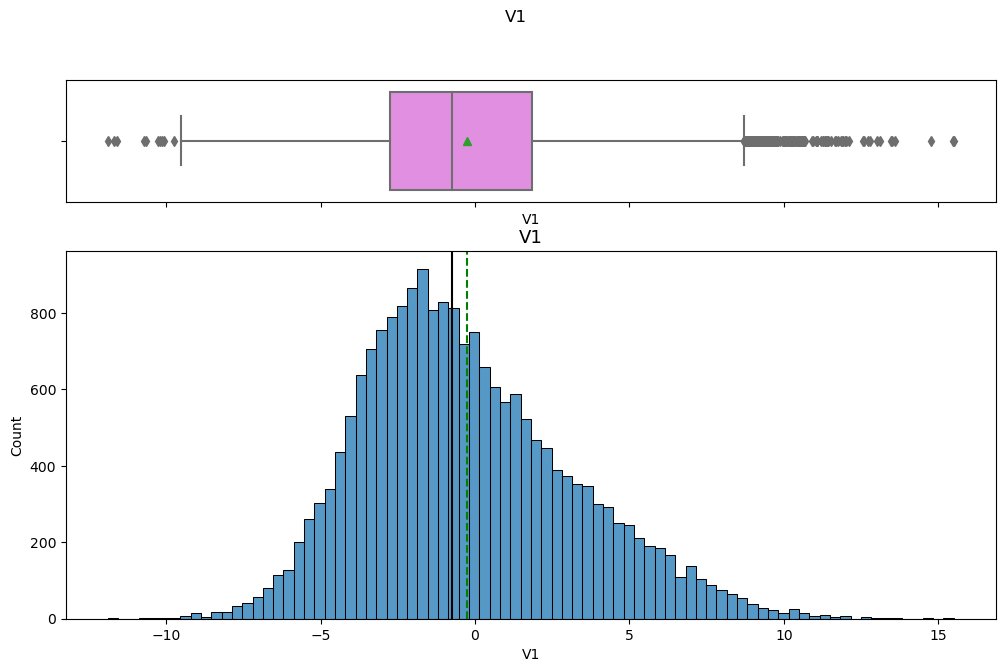

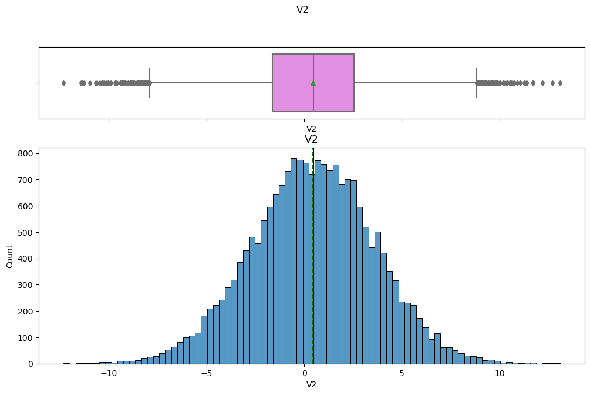

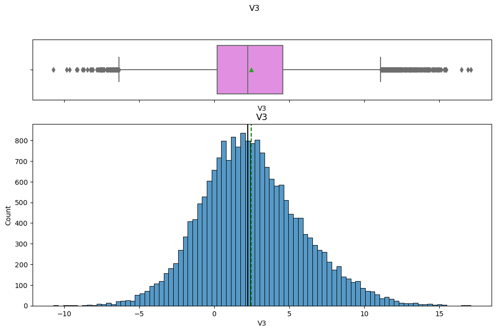

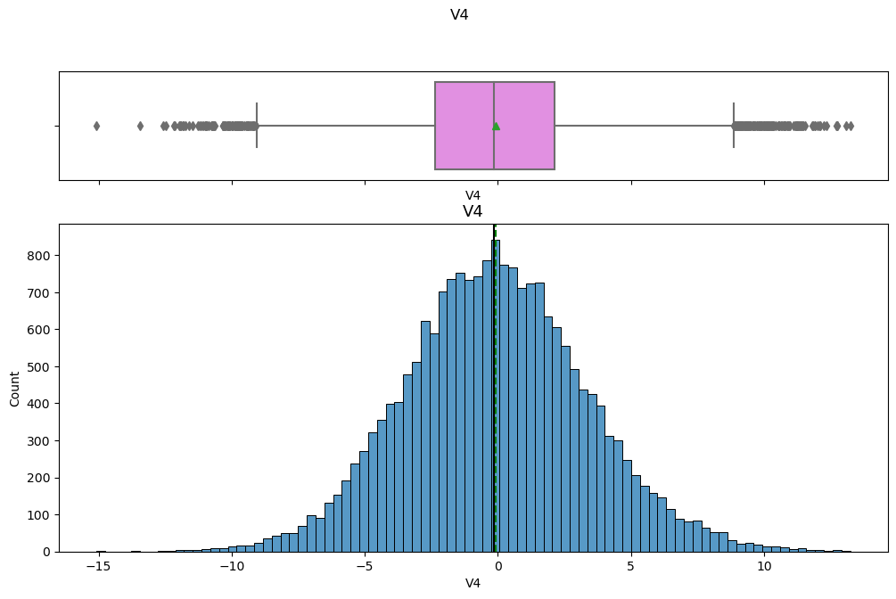

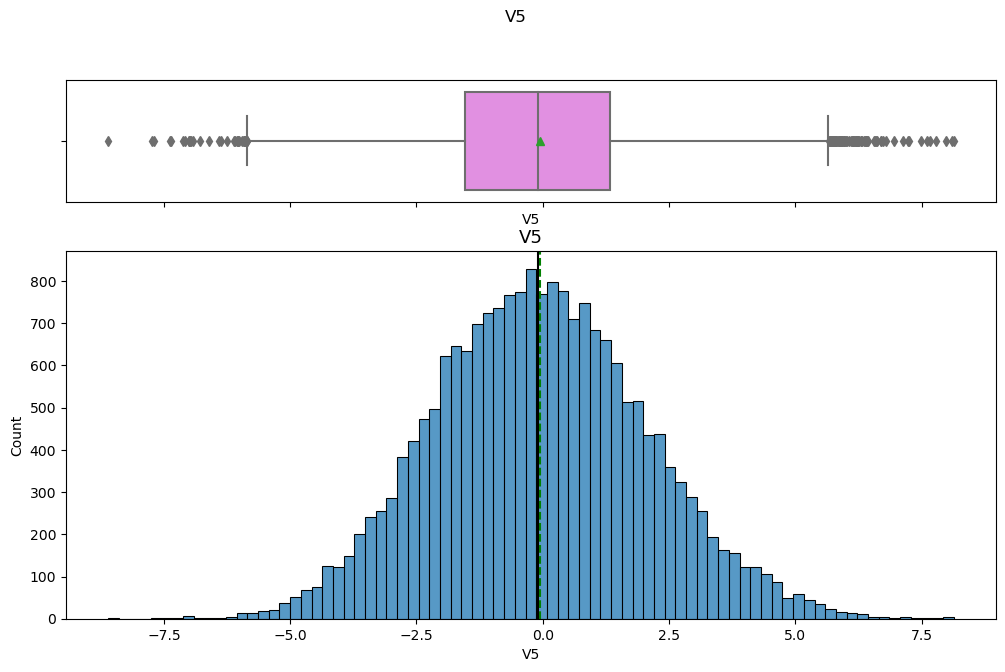

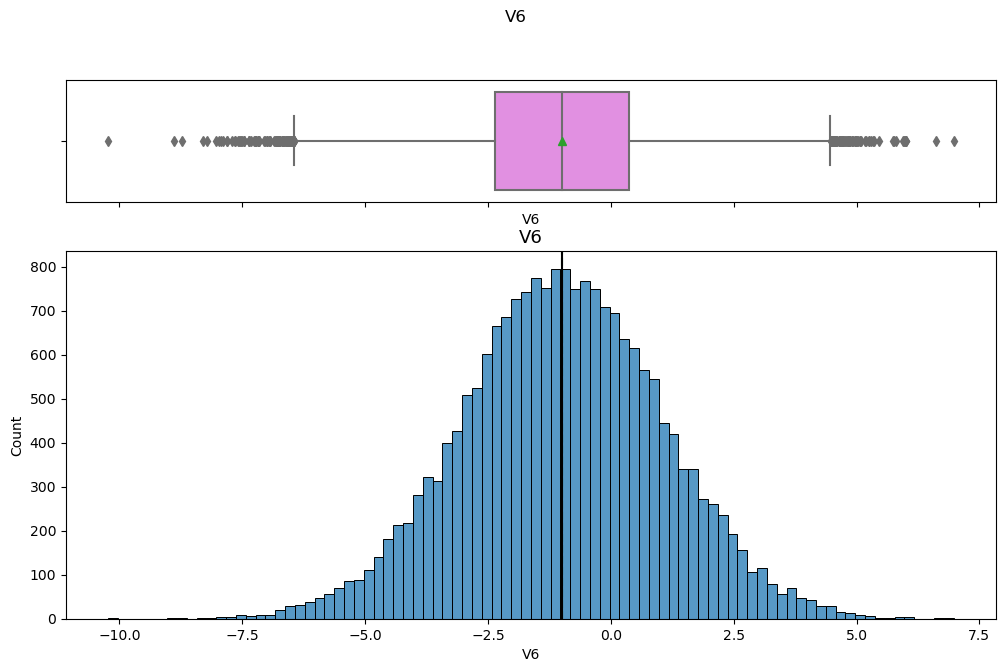

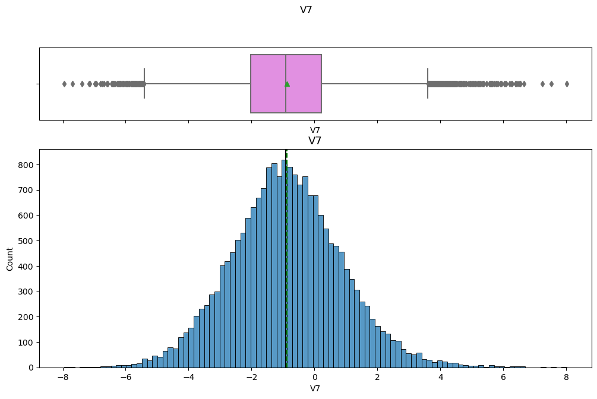

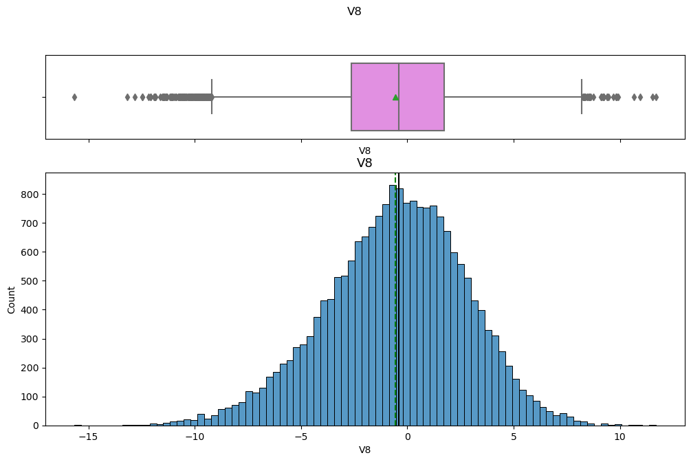

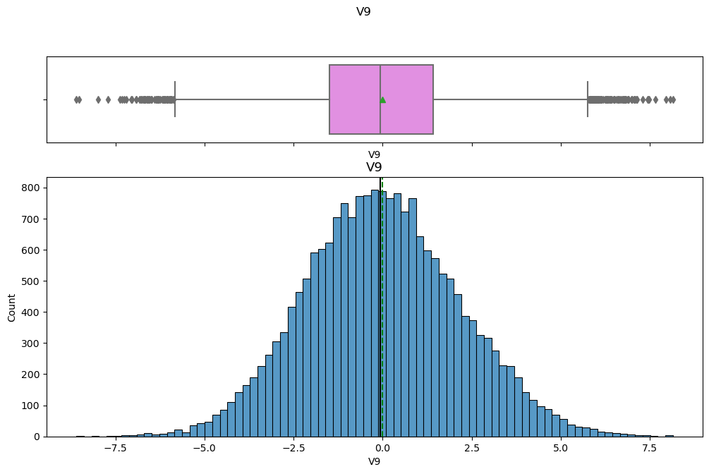

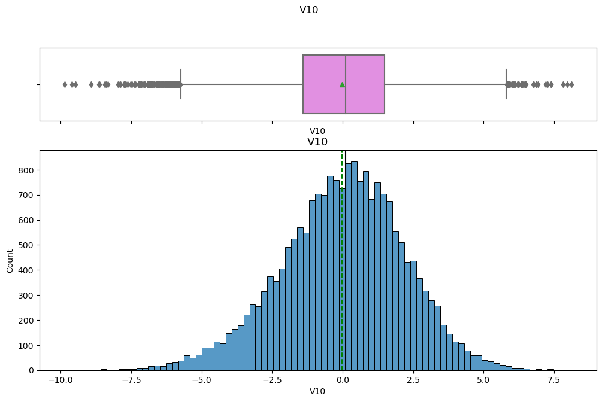

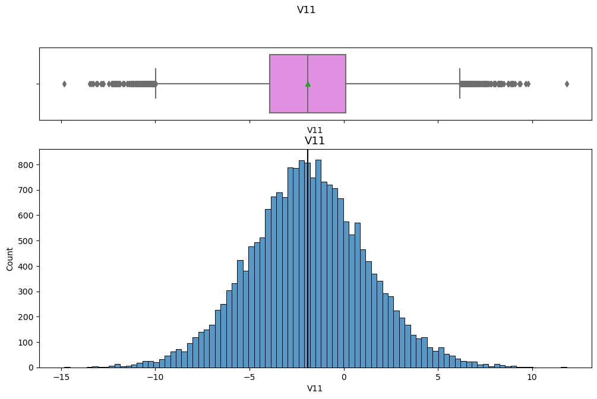

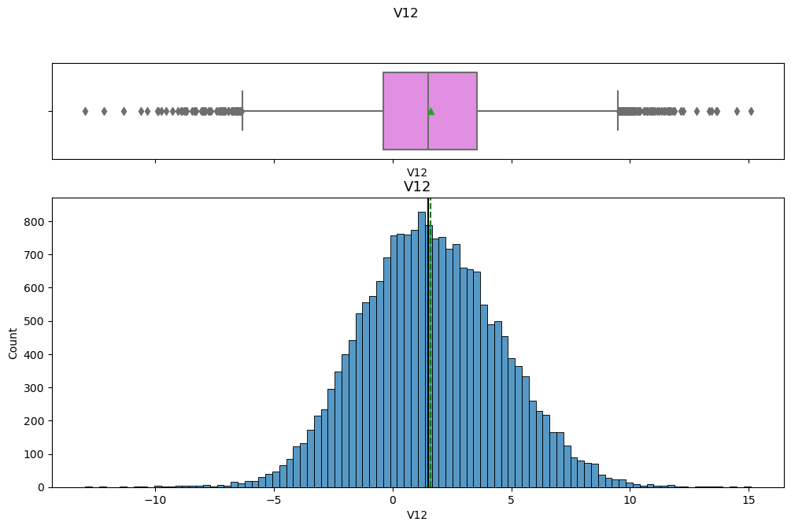

[29 more figures not shown]

```python
for feature in df.columns:
    histogram_boxplot(df, feature, figsize=(12, 7), kde=False, bins=None)
```

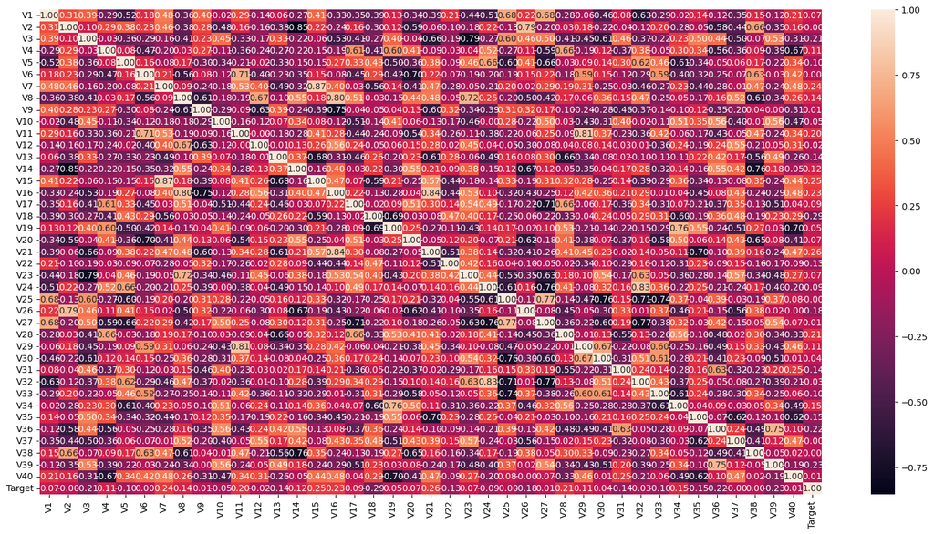

```python
plt.figure(figsize=(20,10))
sns.heatmap(df.corr(), annot=True, fmt='.2f')
```

**Observations**:

1. All the feature are mostly normally distributed.
2. All the columns contain outliers on both the end of dataset.
3. As not information are available about features, we will consider these outliers as real values not treat them.
4. Few variables have high correlation with each other and might have issue of multicollinearity.

### Let's look at the values in target variable

```
0    18890
1     1110
Name: Target, dtype: int64
```

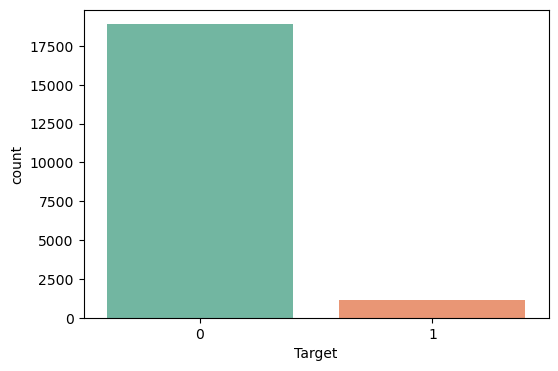

```python
print(df["Target"].value_counts());

plt.figure(figsize=(6, 4))
sns.countplot(data = df, x = 'Target', palette = 'Set2')
plt.show()
```

```python
dftest["Target"].value_counts()
```

```
0    4718
1     282
Name: Target, dtype: int64
```

**Observations**:

1. The training data has inbalanced data set for 'Target' vairable with 94.5% of 0 meaning "no failure" vs 5.5% of 1 (meaning:failure).
2. The test data is inbalance with 94.3% of 0 (no-failures) and 5.6% of 1 (failures)

## Data Pre-processing

```python
# Dividing train data into X and y
X = df.drop(["Target"], axis=1)
y = df["Target"]
```

```python
# Dividing test data into X_test and y_test
X_test = dftest.drop(['Target'], axis = 1)
y_test = dftest['Target']
```

```python
X_test.shape, y_test.shape
```

```
((5000, 40), (5000,))
```

**Since we already have a separate test set, we don't need to divide data into train, valiation and test**

```python
# splitting data in train and validation sets
X_train, X_val, y_train, y_val = train_test_split(X, y, test_size=0.25, random_state=1,  stratify=y)
```

```python
# Checking the number of rows and columns in the X_train and X_val data
print(X_train.shape, X_val.shape, X_test.shape)
```

```
(15000, 40) (5000, 40) (5000, 40)
```

## Missing value imputation

```python
# creating an instace of the imputer to be used
imputer = SimpleImputer(strategy="median")
```

```python
# Fit and transform the train data
X_train = pd.DataFrame(imputer.fit_transform(X_train), columns=X_train.columns)

# Transform the validation data
X_val = pd.DataFrame(imputer.transform(X_val), columns=X_train.columns)

# Transform the test data
X_test = pd.DataFrame(imputer.transform(X_test), columns=X_train.columns)
```

```python
# Checking that no column has missing values in train or test sets
print(X_train.isna().sum())
print("-" * 30)
print(X_val.isna().sum())
print("-" * 30)
print(X_test.isna().sum())
```

```
V1     0
V2     0
V3     0
V4     0
V5     0
V6     0
V7     0
V8     0
V9     0
V10    0
V11    0
V12    0
V13    0
V14    0
V15    0
V16    0
V17    0
V18    0
V19    0
V20    0
V21    0
V22    0
V23    0
V24    0
V25    0
V26    0
V27    0
V28    0
V29    0
V30    0
V31    0
V32    0
V33    0
V34    0
V35    0
V36    0
V37    0
V38    0
V39    0
V40    0
```

[output cut: 70 more lines]

```
V27    0
V28    0
V29    0
V30    0
V31    0
V32    0
V33    0
V34    0
V35    0
V36    0
V37    0
V38    0
V39    0
V40    0
dtype: int64
```

**Observation**:

1. There are no missing values left in any dataset.

## Model Building

### Model evaluation criterion

The nature of predictions made by the classification model will translate as follows:

- True positives (TP) are failures correctly predicted by the model.
- False negatives (FN) are real failures in a generator where there is no detection by model.
- False positives (FP) are failure detections in a generator where there is no failure.

**Which metric to optimize?**

- We need to choose the metric which will ensure that the maximum number of generator failures are predicted correctly by the model.
- We would want Recall to be maximized as greater the Recall, the higher the chances of minimizing false negatives.
- We want to minimize false negatives because if a model predicts that a machine will have no failure when there will be a failure, it will increase the maintenance cost.

**Let's define a function to output different metrics (including recall) on the train and test set and a function to show confusion matrix so that we do not have to use the same code repetitively while evaluating models.**

```python
# defining a function to compute different metrics to check performance of a classification model built using sklearn
def model_performance_classification_sklearn(model, predictors, target):
    """
    Function to compute different metrics to check classification model performance

    model: classifier
    predictors: independent variables
    target: dependent variable
    """

    # predicting using the independent variables
    pred = model.predict(predictors)

    acc = accuracy_score(target, pred)  # to compute Accuracy
    recall = recall_score(target, pred)  # to compute Recall
    precision = precision_score(target, pred)  # to compute Precision
    f1 = f1_score(target, pred)  # to compute F1-score

    # creating a dataframe of metrics
    df_perf = pd.DataFrame(
        {
            "Accuracy": acc,
            "Recall": recall,
            "Precision": precision,
            "F1": f1

        },
        index=[0],
    )

    return df_perf
```

```python
def confusion_matrix_sklearn(model, predictors, target):
    """
    To plot the confusion_matrix with percentages

    model: classifier
    predictors: independent variables
    target: dependent variable
    """
    y_pred = model.predict(predictors)
    cm = confusion_matrix(target, y_pred)
    labels = np.asarray(
        [
            ["{0:0.0f}".format(item) + "\n{0:.2%}".format(item / cm.flatten().sum())]
            for item in cm.flatten()
        ]
    ).reshape(2, 2)

    plt.figure(figsize=(6, 4))
    sns.heatmap(cm, annot=labels, fmt="")
    plt.ylabel("True label")
    plt.xlabel("Predicted label")
```

### Defining scorer to be used for cross-validation and hyperparameter tuning

- We want to reduce false negatives and will try to maximize "Recall".
- To maximize Recall, we can use Recall as a **scorer** in cross-validation and hyperparameter tuning.

```python
# Type of scoring used to compare parameter combinations
scorer = metrics.make_scorer(metrics.recall_score)
```

**We are now done with pre-processing and evaluation criterion, so let's start building the model.**

### Model Building with original data

**Let's start by building different models using K-Fold cross_val_score**

- `Stratified K-Folds cross-validation` provides dataset indices to split data into train/validation sets. Split dataset into k consecutive folds (without shuffling by default) keeping the distribution of both classes in each fold the same as the target variable. Each fold is then used once as validation while the k - 1 remaining folds form the training set.

**We are now done with pre-processing and evaluation criterion, so let's start building the model**

```python
%%time
models = []  # Empty list to store all the models
# Appending models into the list
models.append(("Logistic regression", LogisticRegression(random_state=1)))
models.append(("dtree", DecisionTreeClassifier(random_state=1)))
models.append(("Bagging", BaggingClassifier(random_state=1)))
models.append(("Random forest", RandomForestClassifier(random_state=1)))
models.append(("GBM", GradientBoostingClassifier(random_state=1)))
models.append(("Adaboost", AdaBoostClassifier(random_state=1)))
models.append(("Xgboost", XGBClassifier(random_state=1, eval_metric="logloss")))


results1 = []  # Empty list to store all model's CV scores
names = []  # Empty list to store name of the models


# loop through all models to get the mean cross validated score
print("\n" "Cross-Validation performance on training dataset:" "\n")

for name, model in models:
    kfold = StratifiedKFold(
        n_splits=5, shuffle=True, random_state=1
    )  # Setting number of splits equal to 5
    cv_result = cross_val_score(
        estimator=model, X=X_train, y=y_train, scoring=scorer, cv=kfold
    )
    results1.append(cv_result)
    names.append(name)
    print("{}: {}".format(name, cv_result.mean()))

print('****'*10)

print("\n" "Validation Performance:" "\n")

for name, model in models:
    model.fit(X_train, y_train)
    scores = recall_score(y_val, model.predict(X_val))
    print("{}: {}".format(name, scores))
```

```
Cross-Validation performance on training dataset:

Logistic regression: 0.4927566553639709
dtree: 0.6982829521679532
Bagging: 0.7210807301060529
Random forest: 0.7235192266070268
GBM: 0.7066661857008874
Adaboost: 0.6309140754635308
Xgboost: 0.7956208065796118

Validation Performance:

Logistic regression: 0.48201438848920863
dtree: 0.7050359712230215
Bagging: 0.7302158273381295
Random forest: 0.7266187050359713
GBM: 0.7230215827338129
Adaboost: 0.6762589928057554
Xgboost: 0.8201438848920863
CPU times: total: 9min 10s
Wall time: 6min 31s
```

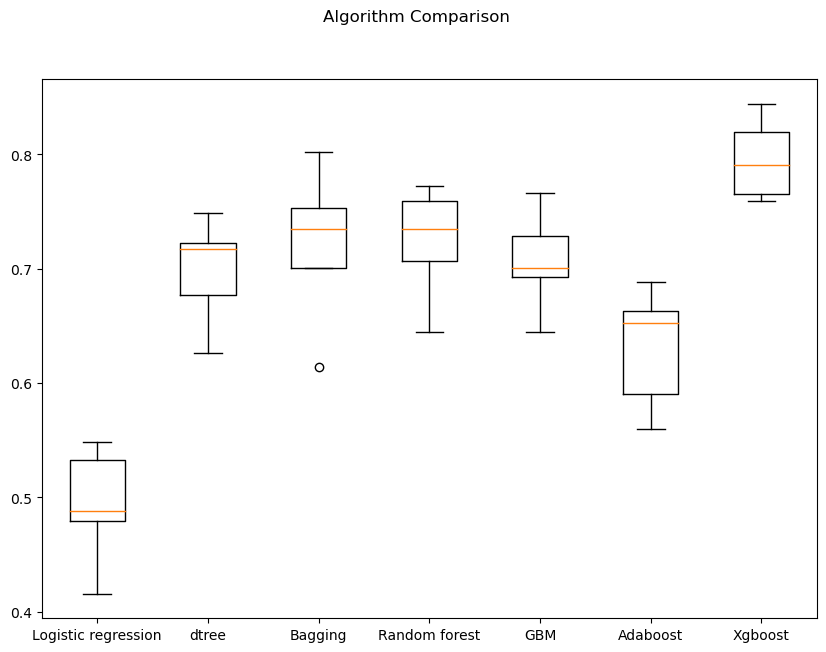

```python
# Plotting boxplots for CV scores of all models defined above
fig = plt.figure(figsize=(10, 7))

fig.suptitle("Algorithm Comparison")
ax = fig.add_subplot(111)

plt.boxplot(results1)
ax.set_xticklabels(names)

plt.show()
```

**Observation**:

1. The cross validation score of training data and validation performance score are pretty close therefore default algrithms are going to generalize well for unknown data set.
2. All other models are performing well with recall around .7 on train and validation set except logistic regression.
3. The perfromance of XGBoost model is best with .82 recall for validation data set.
4. The bagging is 2nd best performing model but has presence of outlier.

#### Checking models performance on training set

```python
print("\n" "Training Performance:" "\n")

for name, model in models:
    model.fit(X_train, y_train)
    scores = model_performance_classification_sklearn(
    model, X_train, y_train
)
    print("{}\n {}".format(name, scores))
```

```
Training Performance:

Logistic regression
    Accuracy  Recall  Precision    F1
0     0.967   0.495      0.843 0.624
dtree
    Accuracy  Recall  Precision    F1
0     1.000   1.000      1.000 1.000
Bagging
    Accuracy  Recall  Precision    F1
0     0.997   0.957      0.997 0.977
Random forest
    Accuracy  Recall  Precision    F1
0     1.000   1.000      1.000 1.000
GBM
    Accuracy  Recall  Precision    F1
0     0.990   0.823      0.986 0.897
Adaboost
    Accuracy  Recall  Precision    F1
0     0.978   0.659      0.923 0.769
Xgboost
    Accuracy  Recall  Precision    F1
0     1.000   1.000      1.000 1.000
```

#### Checking models performance on validation set

```python
print("\n" "Validation Performance:" "\n")

for name, model in models:
    model.fit(X_train, y_train)
    scores = model_performance_classification_sklearn(
    model, X_val, y_val)
    print("{}\n {}".format(name, scores))
```

```
Validation Performance:

Logistic regression
    Accuracy  Recall  Precision    F1
0     0.966   0.482      0.843 0.613
dtree
    Accuracy  Recall  Precision    F1
0     0.966   0.705      0.688 0.696
Bagging
    Accuracy  Recall  Precision    F1
0     0.983   0.730      0.949 0.825
Random forest
    Accuracy  Recall  Precision    F1
0     0.984   0.727      0.985 0.836
GBM
    Accuracy  Recall  Precision    F1
0     0.980   0.723      0.905 0.804
Adaboost
    Accuracy  Recall  Precision    F1
0     0.976   0.676      0.866 0.760
Xgboost
    Accuracy  Recall  Precision    F1
0     0.989   0.820      0.974 0.891
```

**Observations**:

### Model Building with Oversampled data

**To handle class imbalance for the "Target" attribute, Synthetic Minority Oversampling Technique SMOTE is employed to generate synthetic data points for minority class. Both classes (0 and 1) will be equal in number after oversampling technique.**

```python
# Synthetic Minority Over Sampling Technique
print("Before OverSampling, counts of label '1': {}".format(sum(y_train == 1)))
print("Before OverSampling, counts of label '0': {} \n".format(sum(y_train == 0)))

sm = SMOTE(sampling_strategy=1, k_neighbors=5, random_state=1)
X_train_over, y_train_over = sm.fit_resample(X_train, y_train)


print("After OverSampling, counts of label '1': {}".format(sum(y_train_over == 1)))
print("After OverSampling, counts of label '0': {} \n".format(sum(y_train_over == 0)))


print("After OverSampling, the shape of train_X: {}".format(X_train_over.shape))
print("After OverSampling, the shape of train_y: {} \n".format(y_train_over.shape))
```

```
Before OverSampling, counts of label '1': 832
Before OverSampling, counts of label '0': 14168

After OverSampling, counts of label '1': 14168
After OverSampling, counts of label '0': 14168

After OverSampling, the shape of train_X: (28336, 40)
After OverSampling, the shape of train_y: (28336,)
```

The data with label 1 (minority class) has been synthically generated to reach 14168 equal to number of '0's in dataset.

```python
%%time
modelsover = []  # Empty list to store all the models
# Appending models into the list
modelsover.append(("Logistic regression", LogisticRegression(random_state=1)))
modelsover.append(("dtree", DecisionTreeClassifier(random_state=1)))
modelsover.append(("Bagging", BaggingClassifier(random_state=1)))
modelsover.append(("Random forest", RandomForestClassifier(random_state=1)))
modelsover.append(("GBM", GradientBoostingClassifier(random_state=1)))
modelsover.append(("Adaboost", AdaBoostClassifier(random_state=1)))
modelsover.append(("Xgboost", XGBClassifier(random_state=1, eval_metric="logloss")))


resultsover = []  # Empty list to store all model's CV scores
names_over = []  # Empty list to store name of the models


# loop through all models to get the mean cross validated score
print("\n" "Cross-Validation performance on training dataset:" "\n")

for name, model in modelsover:
    kfold = StratifiedKFold(
        n_splits=5, shuffle=True, random_state=1
    )  # Setting number of splits equal to 5
    cv_result = cross_val_score(
        estimator=model, X=X_train_over, y=y_train_over, scoring=scorer, cv=kfold
    )
    resultsover.append(cv_result)
    names_over.append(name)

    print("{}: {}".format(name, cv_result.mean()))
```

```
Cross-Validation performance on training dataset:

Logistic regression: 0.883963699328486
dtree: 0.9720494245534969
Bagging: 0.9762141471581656
Random forest: 0.9839075260047615
GBM: 0.9256068151319724
Adaboost: 0.8978689011775473
Xgboost: 0.989554053559209
CPU times: total: 16min 17s
Wall time: 9min 33s
```

```python
print("\n" "Validation Performance:" "\n")

for name, model in modelsover:
    model.fit(X_train_over, y_train_over)
    scores = recall_score(y_val, model.predict(X_val))
    print("{}: {}".format(name, scores))
```

```
Validation Performance:

Logistic regression: 0.8489208633093526
dtree: 0.7769784172661871
Bagging: 0.8345323741007195
Random forest: 0.8489208633093526
GBM: 0.8776978417266187
Adaboost: 0.8561151079136691
Xgboost: 0.8669064748201439
```

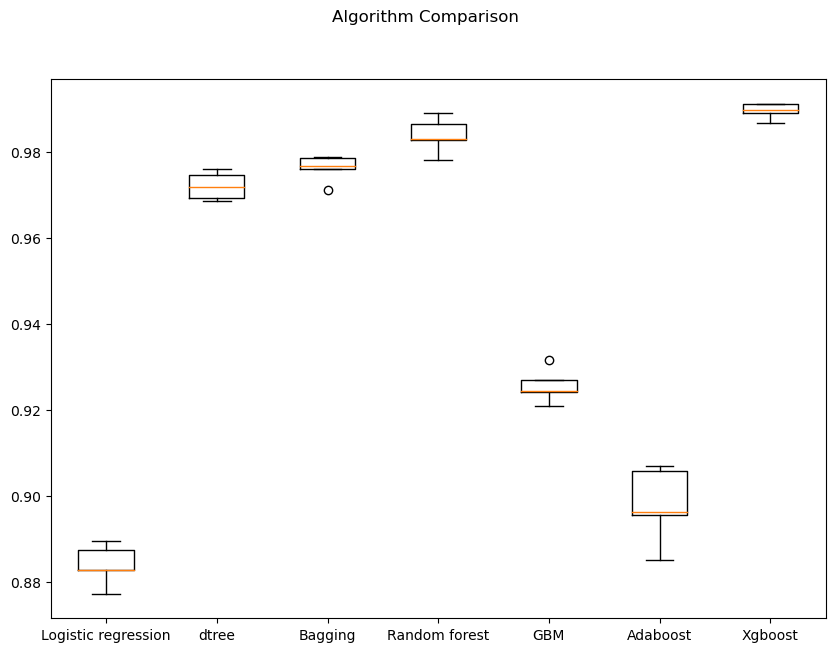

```python
# Plotting boxplots for CV scores of all models defined above
fig = plt.figure(figsize=(10, 7))

fig.suptitle("Algorithm Comparison")
ax = fig.add_subplot(111)

plt.boxplot(resultsover)
ax.set_xticklabels(names_over)

plt.show()
```

**Observations**:

1. The logistic regression corss validation score is .88 quite close to .85 of validation set.
2. The cross validation score of decision tree, bagging, random forest and Xgboost is around .97 quite higher than validation scores which means these models will not be able to generalize well in production.
3. The cross validation score for Adaboost model is .89 quite close to .86 of validation set. This model with oversampled dataset can be improved further with hypertuning.
4. The cross validation score for Gradient boost model is .92 .quite close to .877 of validation set. The model has one outlier with oversampled dataset and can be improved further with hypertuning.

#### Checking models performance on training set

```python
print("\n" "Training Performance:" "\n")

for name, model in modelsover:
    model.fit(X_train_over, y_train_over)
    scores = model_performance_classification_sklearn(
    model, X_train_over, y_train_over
)
    print("{}\n {}".format(name, scores))
```

```
Training Performance:

Logistic regression
    Accuracy  Recall  Precision    F1
0     0.880   0.884      0.878 0.881
dtree
    Accuracy  Recall  Precision    F1
0     1.000   1.000      1.000 1.000
Bagging
    Accuracy  Recall  Precision    F1
0     0.999   0.998      1.000 0.999
Random forest
    Accuracy  Recall  Precision    F1
0     1.000   1.000      1.000 1.000
GBM
    Accuracy  Recall  Precision    F1
0     0.954   0.931      0.976 0.953
Adaboost
    Accuracy  Recall  Precision    F1
0     0.914   0.903      0.923 0.913
Xgboost
    Accuracy  Recall  Precision    F1
0     1.000   1.000      1.000 1.000
```

#### Checking models performance on validation set

```python
print("\n" "Validation Performance:" "\n")

for name, model in modelsover:
    model.fit(X_train_over, y_train_over)
    scores = model_performance_classification_sklearn(
    model, X_val, y_val)
    print("{}\n {}".format(name, scores))
```

```
Validation Performance:

Logistic regression
    Accuracy  Recall  Precision    F1
0     0.868   0.849      0.277 0.418
dtree
    Accuracy  Recall  Precision    F1
0     0.949   0.777      0.531 0.631
Bagging
    Accuracy  Recall  Precision    F1
0     0.980   0.835      0.806 0.820
Random forest
    Accuracy  Recall  Precision    F1
0     0.988   0.849      0.937 0.891
GBM
    Accuracy  Recall  Precision    F1
0     0.964   0.878      0.622 0.728
Adaboost
    Accuracy  Recall  Precision    F1
0     0.912   0.856      0.374 0.520
Xgboost
    Accuracy  Recall  Precision    F1
0     0.988   0.867      0.920 0.893
```

**Observations**:

1. The logistic regression training scores of accuracy and recall are .88 quite close to validation set accuracy if .868 and recall of 84. There is huge drop in precision and F1 score on validation data.
2. The training score of decision tree, bagging, random forest and Xgboost clearly indicates too much overfitting with all scores apporximately ~ 1. The accuracy of validation dataset is quite high of .98 as well for random forest, bagging and Xgboost algorithms.
3. As cross validation score are pretty high too for above 4 models these models are quite overfitting with training noise in it.
4. The Adaboost accuracy for training set is .914 quite close to .912 of validation set. The precision and F1 score has fallen drastically on validation data.
5. The Gradient Boost accuracy for training set is .954 quite close to .964 of validation set. The precision and F1 score has fallen drastically on validation data.
6. Tha Adaboost and GBM models with oversampled data can be improved further using Hypertuning for better perfromance.

### Model Building with Undersampled data

**One more technique to handle class imbalance for the "Target" attribute is Random Undersampling, in which only random samples from the majority class are chosen for modelling. After random undersampling, we again have equal number of both class (1 and 0) but loose information due to less datapoints**

```python
# Random undersampler for under sampling the data
rus = RandomUnderSampler(random_state=1, sampling_strategy=1)
X_train_un, y_train_un = rus.fit_resample(X_train, y_train)


print("Before UnderSampling, counts of label '1': {}".format(sum(y_train == 1)))
print("Before UnderSampling, counts of label '0': {} \n".format(sum(y_train == 0)))


print("After UnderSampling, counts of label '1': {}".format(sum(y_train_un == 1)))
print("After UnderSampling, counts of label '0': {} \n".format(sum(y_train_un == 0)))


print("After UnderSampling, the shape of train_X: {}".format(X_train_un.shape))
print("After UnderSampling, the shape of train_y: {} \n".format(y_train_un.shape))
```

```
Before UnderSampling, counts of label '1': 832
Before UnderSampling, counts of label '0': 14168

After UnderSampling, counts of label '1': 832
After UnderSampling, counts of label '0': 832

After UnderSampling, the shape of train_X: (1664, 40)
After UnderSampling, the shape of train_y: (1664,)
```

Only 832 data samples are been randomly selected from major class "0" and therefore shape of data been reduced to 1664.

```python
%%time
modelsunder = []  # Empty list to store all the models
# Appending models into the list
modelsunder.append(("Logistic regression", LogisticRegression(random_state=1)))
modelsunder.append(("dtree", DecisionTreeClassifier(random_state=1)))
modelsunder.append(("Bagging", BaggingClassifier(random_state=1)))
modelsunder.append(("Random forest", RandomForestClassifier(random_state=1)))
modelsunder.append(("GBM", GradientBoostingClassifier(random_state=1)))
modelsunder.append(("Adaboost", AdaBoostClassifier(random_state=1)))
modelsunder.append(("Xgboost", XGBClassifier(random_state=1, eval_metric="logloss")))


resultsunder = []  # Empty list to store all model's CV scores
names_under = []  # Empty list to store name of the models


# loop through all models to get the mean cross validated score
print("\n" "Cross-Validation performance on training dataset:" "\n")

for name, model in modelsover:
    kfold = StratifiedKFold(
        n_splits=5, shuffle=True, random_state=1
    )  # Setting number of splits equal to 5
    cv_result = cross_val_score(
        estimator=model, X=X_train_un, y=y_train_un, scoring=scorer, cv=kfold
    )
    resultsunder.append(cv_result)
    names_under.append(name)

    print("{}: {}".format(name, cv_result.mean()))
```

```
Cross-Validation performance on training dataset:

Logistic regression: 0.8726138085275232
dtree: 0.8617776495202367
Bagging: 0.8641945025611427
Random forest: 0.9038669648654498
GBM: 0.8978572974532861
Adaboost: 0.8666113556020489
Xgboost: 0.9074742082100858
CPU times: total: 37.1 s
Wall time: 27 s
```

```python
print("\n" "Validation Performance:" "\n")

for name, model in modelsunder:
    model.fit(X_train_un, y_train_un)
    scores = recall_score(y_val, model.predict(X_val))
    print("{}: {}".format(name, scores))
```

```
Validation Performance:

Logistic regression: 0.8525179856115108
dtree: 0.841726618705036
Bagging: 0.8705035971223022
Random forest: 0.8920863309352518
GBM: 0.8884892086330936
Adaboost: 0.8489208633093526
Xgboost: 0.9028776978417267
```

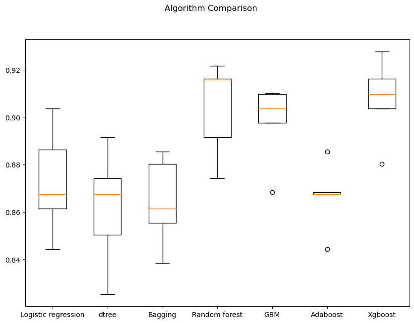

```python
# Plotting boxplots for CV scores of all models defined above
fig = plt.figure(figsize=(10, 7))

fig.suptitle("Algorithm Comparison")
ax = fig.add_subplot(111)

plt.boxplot(resultsunder)
ax.set_xticklabels(names_under)

plt.show()
```

**Observations**:

#### Checking models performance on training set

```python
print("\n" "Training Performance :" "\n")

for name, model in modelsunder:
    model.fit(X_train_un, y_train_un)
    scores = model_performance_classification_sklearn(
    model, X_train_un, y_train_un
)
    print("{}\n {}".format(name, scores))
```

```
Training Performance :

Logistic regression
    Accuracy  Recall  Precision    F1
0     0.873   0.875      0.872 0.873
dtree
    Accuracy  Recall  Precision    F1
0     1.000   1.000      1.000 1.000
Bagging
    Accuracy  Recall  Precision    F1
0     0.990   0.983      0.998 0.990
Random forest
    Accuracy  Recall  Precision    F1
0     1.000   1.000      1.000 1.000
GBM
    Accuracy  Recall  Precision    F1
0     0.965   0.940      0.989 0.964
Adaboost
    Accuracy  Recall  Precision    F1
0     0.922   0.905      0.938 0.921
Xgboost
    Accuracy  Recall  Precision    F1
0     1.000   1.000      1.000 1.000
```

#### Checking models performance on validation set

```python
print("\n" "Validation Performance:" "\n")

for name, model in modelsunder:
    model.fit(X_train_un, y_train_un)
    scores = model_performance_classification_sklearn(
    model, X_val, y_val)
    print("{}\n {}".format(name, scores))
```

```
Validation Performance:

Logistic regression
    Accuracy  Recall  Precision    F1
0     0.857   0.853      0.260 0.399
dtree
    Accuracy  Recall  Precision    F1
0     0.831   0.842      0.226 0.356
Bagging
    Accuracy  Recall  Precision    F1
0     0.928   0.871      0.428 0.574
Random forest
    Accuracy  Recall  Precision    F1
0     0.947   0.892      0.515 0.653
GBM
    Accuracy  Recall  Precision    F1
0     0.930   0.888      0.438 0.587
Adaboost
    Accuracy  Recall  Precision    F1
0     0.877   0.849      0.292 0.435
Xgboost
    Accuracy  Recall  Precision    F1
0     0.950   0.903      0.531 0.668
```

**Observations**:

## HyperparameterTuning

### **Note**

1. Sample parameter grid has been provided to do necessary hyperparameter tuning. One can extend/reduce the parameter grid based on execution time and system configuration to try to improve the model performance further wherever needed.
2. The models chosen in this notebook are based on test runs. One can update the best models as obtained upon code execution and tune them for best performance.

### Tuning AdaBoost using oversampled data

#### RandomSearchCV

```python
%%time

# defining model
abc_tuned = AdaBoostClassifier(random_state=1)

# Parameter grid to pass in RandomSearchCV
param_grid = {
    "n_estimators": [100, 150, 200],
    "learning_rate": [0.2, 0.05],
    "base_estimator": [DecisionTreeClassifier(max_depth=1, random_state=1),
                       DecisionTreeClassifier(max_depth=2, random_state=1),
                       DecisionTreeClassifier(max_depth=3, random_state=1),
    ]
}


#Calling RandomizedSearchCV
randomized_cv = RandomizedSearchCV(estimator=abc_tuned, param_distributions=param_grid, n_iter=50,
                                   n_jobs = -1, scoring=scorer, cv=5, random_state=1)

#Fitting parameters in RandomizedSearchCV
randomized_cv.fit(X_train_over,y_train_over) ## Complete the code to fit the model on over sampled data

print("Best parameters are {} with CV score={}:" .format(randomized_cv.best_params_,randomized_cv.best_score_))

# Set the clf to the best combination of parameters
abc_tuned = randomized_cv.best_estimator_

# Fit the best algorithm to the data.
abc_tuned.fit(X_train_over, y_train_over)
```

```
Best parameters are {'n_estimators': 200, 'learning_rate': 0.2, 'base_estimator': DecisionTreeClassifier(max_depth=3, random_state=1)} with CV score=0.971555946263926:
CPU times: total: 4min 52s
Wall time: 27min 43s
```

```
AdaBoostClassifier(base_estimator=DecisionTreeClassifier(max_depth=3,
                                                         random_state=1),
                   learning_rate=0.2, n_estimators=200, random_state=1)
```

*As dataset is increased 28336 samples with SMOTE, even RandomsearchCV took 27 mins for hypertuning therefore will not try GridsearchCV for hypertuning*

#### Checking models performance on training set

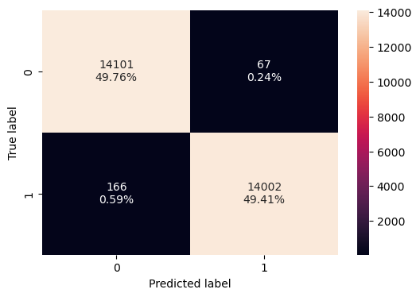

```python
confusion_matrix_sklearn(abc_tuned,X_train_over,y_train_over)
```

```python
abc_tuned_model_train=model_performance_classification_sklearn(abc_tuned,X_train_over,y_train_over)
abc_tuned_model_train
```

|  | Accuracy | Recall | Precision | F1 |
| --- | --- | --- | --- | --- |
| 0 | 0.992 | 0.988 | 0.995 | 0.992 |

#### Checking models performance on validation set

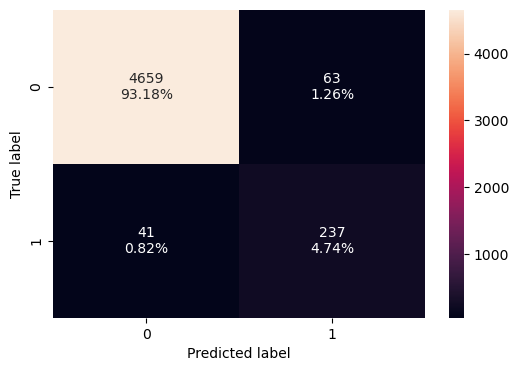

```python
confusion_matrix_sklearn(abc_tuned,X_val,y_val)
```

```python
abc_tuned_model_val=model_performance_classification_sklearn(abc_tuned, X_val, y_val)
abc_tuned_model_val
```

|  | Accuracy | Recall | Precision | F1 |
| --- | --- | --- | --- | --- |
| 0 | 0.979 | 0.853 | 0.790 | 0.820 |

**Observation**:

1. The abc_tuned_model is quite overfitting the training data with .99 for accuracy, .98 for recall, .99 for precision and .992 for f1.
2. The accuracy for validation dataset is .98 but recall is still .85 like AdaBoostClassifier model .
3. The precision and f1 scores on validation data has improved from AdaBoostClassifier model.
4. Hypertuning has definately improved precision, f1, and accuracy on validation set.

### Tuning Gradient Boosting using oversampled data

#### RandomSearchCV

```python
%%time

# defining model
gb_tuned = GradientBoostingClassifier(random_state=1)

#Parameter grid to pass in RandomSearchCV
param_grid={"n_estimators": np.arange(100,150,25),
            "learning_rate": [0.2, 0.05, 1],
            "subsample":[0.5,0.7],
            "max_features":[0.5,0.7]}

#Calling RandomizedSearchCV
randomized_cv = RandomizedSearchCV(estimator=gb_tuned,
                                   param_distributions=param_grid,
                                   scoring=scorer, n_iter=30, n_jobs = -1, cv=5, random_state=1)

#Fitting parameters in RandomizedSearchCV
randomized_cv.fit(X_train_over, y_train_over)

print("Best parameters are {} with CV score={}:" .format(randomized_cv.best_params_,randomized_cv.best_score_))

# Set the clf to the best combination of parameters
gb_tuned = randomized_cv.best_estimator_

# Fit the best algorithm to the data.
gb_tuned.fit(X_train_over, y_train_over)
```

```
Best parameters are {'subsample': 0.7, 'n_estimators': 125, 'max_features': 0.5, 'learning_rate': 1} with CV score=0.9724734023671514:
CPU times: total: 57.4 s
Wall time: 11min 31s
```

```
GradientBoostingClassifier(learning_rate=1, max_features=0.5, n_estimators=125,
                           random_state=1, subsample=0.7)
```

*As dataset is increased 28336 samples with SMOTE, therefore will not try GridsearchCV for hypertuning*

#### Checking models performance on training set

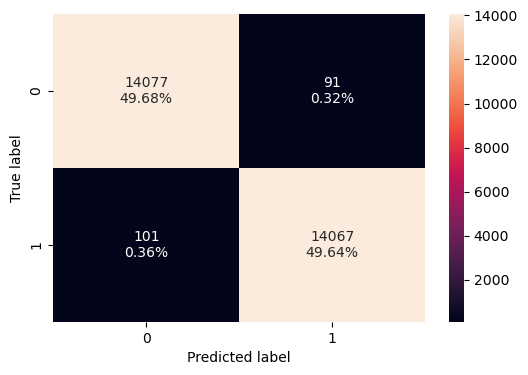

```python
confusion_matrix_sklearn(gb_tuned, X_train_over,y_train_over)
```

```python
gb_tuned_model_train=model_performance_classification_sklearn(gb_tuned,X_train_over,y_train_over)
gb_tuned_model_train
```

|  | Accuracy | Recall | Precision | F1 |
| --- | --- | --- | --- | --- |
| 0 | 0.993 | 0.993 | 0.994 | 0.993 |

#### Checking models performance on validation set

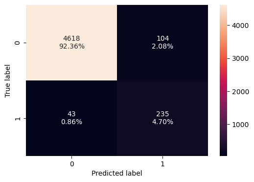

```python
confusion_matrix_sklearn(gb_tuned,X_val,y_val)
```

```python
gb_tuned_model_val=model_performance_classification_sklearn(gb_tuned,X_val,y_val)
gb_tuned_model_val
```

|  | Accuracy | Recall | Precision | F1 |
| --- | --- | --- | --- | --- |
| 0 | 0.971 | 0.845 | 0.693 | 0.762 |

**Observation**:

### Tuning Gradient Boosting using undersampled data

#### RandomSearchCV

```python
%%time

# defining model
gb_tuned_un= GradientBoostingClassifier(random_state=1)

#Parameter grid to pass in RandomSearchCV
param_grid={"n_estimators": np.arange(100,150,25),
            "learning_rate": [0.2, 0.05, 1],
            "subsample":[0.5,0.7],
            "max_features":[0.5,0.7]}

#Calling RandomizedSearchCV
randomized_cv = RandomizedSearchCV(estimator=gb_tuned_un,
                                   param_distributions=param_grid,
                                   scoring=scorer, n_iter=30, n_jobs = -1, cv=5, random_state=1)

#Fitting parameters in RandomizedSearchCV
randomized_cv.fit(X_train_un, y_train_un)

print("Best parameters are {} with CV score={}:" .format(randomized_cv.best_params_,randomized_cv.best_score_))

# Set the clf to the best combination of parameters
gb_tuned_un = randomized_cv.best_estimator_

# Fit the best algorithm to the data.
gb_tuned_un.fit(X_train_un, y_train_un)
```

```
Best parameters are {'subsample': 0.7, 'n_estimators': 125, 'max_features': 0.5, 'learning_rate': 0.2} with CV score=0.9050212827357333:
CPU times: total: 3.59 s
Wall time: 29.3 s
```

```
GradientBoostingClassifier(learning_rate=0.2, max_features=0.5,
                           n_estimators=125, random_state=1, subsample=0.7)
```

#### Checking models performance on training set

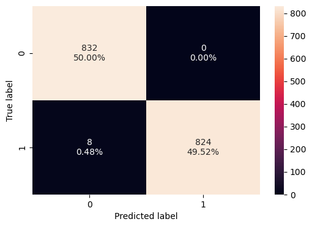

```python
confusion_matrix_sklearn(gb_tuned_un, X_train_un,y_train_un)
```

```python
gb_tuned_un_train=model_performance_classification_sklearn(gb_tuned_un,X_train_un,y_train_un)
gb_tuned_un_train
```

|  | Accuracy | Recall | Precision | F1 |
| --- | --- | --- | --- | --- |
| 0 | 0.995 | 0.990 | 1.000 | 0.995 |

#### Checking models performance on validation set

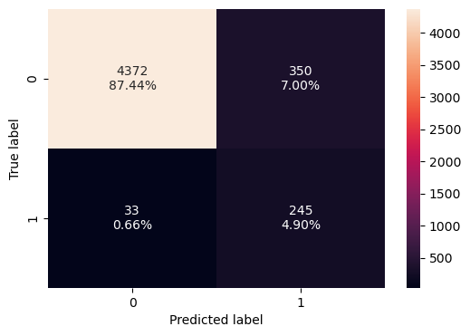

```python
confusion_matrix_sklearn(gb_tuned_un,X_val,y_val)
```

```python
gb_tuned_un_val=model_performance_classification_sklearn(gb_tuned_un,X_val,y_val)
gb_tuned_un_val
```

|  | Accuracy | Recall | Precision | F1 |
| --- | --- | --- | --- | --- |
| 0 | 0.923 | 0.881 | 0.412 | 0.561 |

**Observation**:

#### GridSearchCV

```python
gb_tuned_un2 = GradientBoostingClassifier(random_state=1)

# Grid of parameters to choose from
parameters = {
    "n_estimators": [120, 125],
    "subsample": [0.9, 1],
    "max_features": [0.5, 0.7],
    "learning_rate": [0.5, 0.2],
}


# Run the grid search
grid_obj = GridSearchCV(gb_tuned_un2, parameters, scoring=scorer,cv=3)
grid_obj = grid_obj.fit(X_train_un, y_train_un)

# Set the clf to the best combination of parameters
gb_tuned_un2 = grid_obj.best_estimator_

# Fit the best algorithm to the data.
gb_tuned_un2.fit(X_train_un, y_train_un)
```

```
GradientBoostingClassifier(learning_rate=0.5, max_features=0.5,
                           n_estimators=120, random_state=1, subsample=0.9)
```

#### Checking models performance on training set

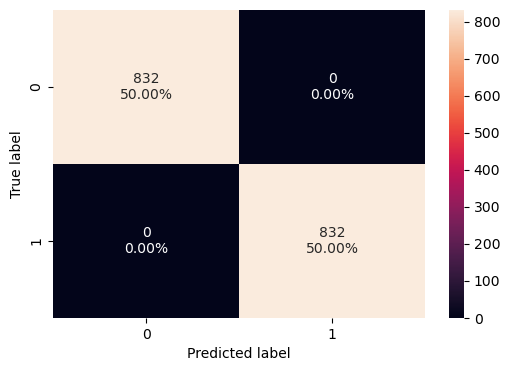

```python
confusion_matrix_sklearn(gb_tuned_un2, X_train_un,y_train_un)
```

```python
gb_tuned_un2_train=model_performance_classification_sklearn(gb_tuned_un2, X_train_un,y_train_un)
gb_tuned_un2_train
```

|  | Accuracy | Recall | Precision | F1 |
| --- | --- | --- | --- | --- |
| 0 | 1.000 | 1.000 | 1.000 | 1.000 |

#### Checking models performance on validation set

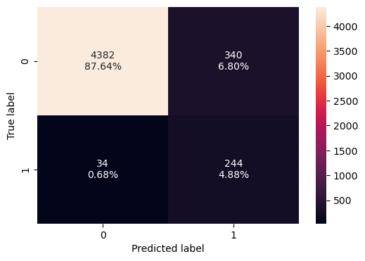

```python
confusion_matrix_sklearn(gb_tuned_un2,X_val,y_val)
```

```python
gb_tuned_un2_val=model_performance_classification_sklearn(gb_tuned_un2,X_val,y_val)
gb_tuned_un2_val
```

|  | Accuracy | Recall | Precision | F1 |
| --- | --- | --- | --- | --- |
| 0 | 0.925 | 0.878 | 0.418 | 0.566 |

**Observation**:

### Tuning Random Forest using undersampled data

#### RandomSearchCV

```python
# Choose the type of classifier.
rf_tuned = RandomForestClassifier(random_state=1, oob_score=True, bootstrap=True)

# Grid of parameters to choose from
param_grid = { "n_estimators": [200,250,300],
              "min_samples_leaf": np.arange(1, 4),
              "max_features": [np.arange(0.3, 0.6, 0.1),'sqrt'],
              "max_samples": np.arange(0.4, 0.7, 0.1) }

#Calling RandomizedSearchCV
randomized_cv = RandomizedSearchCV(estimator=rf_tuned, param_distributions=param_grid,
                                   n_iter=50, n_jobs = -1, scoring=scorer, cv=5, random_state=1)

randomized_cv.fit(X_train_un, y_train_un)

print("Best parameters are {} with CV score={}:" .format(randomized_cv.best_params_,randomized_cv.best_score_))

#Fitting parameters in RandomizedSearchCV
rf_tuned = randomized_cv.best_estimator_

# Fit the best algorithm to the data.
rf_tuned.fit(X_train_un, y_train_un)
```

```
Best parameters are {'n_estimators': 300, 'min_samples_leaf': 2, 'max_samples': 0.5, 'max_features': 'sqrt'} with CV score=0.8990116153235697:
```

```
RandomForestClassifier(max_samples=0.5, min_samples_leaf=2, n_estimators=300,
                       oob_score=True, random_state=1)
```

#### Checking models performance on training set

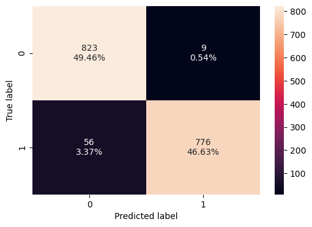

```python
confusion_matrix_sklearn(rf_tuned, X_train_un,y_train_un)
```

```python
rf_tuned_un_train = model_performance_classification_sklearn(rf_tuned, X_train_un,y_train_un)
rf_tuned_un_train
```

|  | Accuracy | Recall | Precision | F1 |
| --- | --- | --- | --- | --- |
| 0 | 0.961 | 0.933 | 0.989 | 0.960 |

#### Checking models performance on validation set

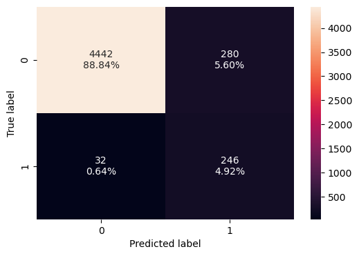

```python
confusion_matrix_sklearn(rf_tuned, X_val,y_val)
```

```python
rf_tuned_un_val = model_performance_classification_sklearn(rf_tuned, X_val,y_val)
rf_tuned_un_val
```

|  | Accuracy | Recall | Precision | F1 |
| --- | --- | --- | --- | --- |
| 0 | 0.938 | 0.885 | 0.468 | 0.612 |

**Observation**:

### Tuning XGBoost using undersampled data

#### RandomSearchCV

```python
# Choose the type of classifier.
xgb_tuned_un = XGBClassifier(random_state=1, eval_metric='logloss')

# Grid of parameters to choose from
param_grid={'n_estimators':[150,200,250],
            'scale_pos_weight':[5,10],
            'learning_rate':[0.1,0.2],
            'gamma':[0,3,5],
            'subsample':[0.8,0.9]}

#Calling RandomizedSearchCV
randomized_cv = RandomizedSearchCV(estimator=xgb_tuned_un, param_distributions=param_grid,
                                   n_iter=50, n_jobs = -1, scoring=scorer, cv=5, random_state=1)

randomized_cv.fit(X_train_un, y_train_un)

print("Best parameters are {} with CV score={}:" .format(randomized_cv.best_params_,randomized_cv.best_score_))

#Fitting parameters in RandomizedSearchCV
xgb_tuned_un = randomized_cv.best_estimator_

# Fit the best algorithm to the data.
xgb_tuned_un.fit(X_train_un, y_train_un)
```

```
Best parameters are {'subsample': 0.8, 'scale_pos_weight': 10, 'n_estimators': 250, 'learning_rate': 0.2, 'gamma': 3} with CV score=0.9266575283168603:
```

```
XGBClassifier(base_score=None, booster=None, callbacks=None,
              colsample_bylevel=None, colsample_bynode=None,
              colsample_bytree=None, early_stopping_rounds=None,
              enable_categorical=False, eval_metric='logloss',
              feature_types=None, gamma=3, gpu_id=None, grow_policy=None,
              importance_type=None, interaction_constraints=None,
              learning_rate=0.2, max_bin=None, max_cat_threshold=None,
              max_cat_to_onehot=None, max_delta_step=None, max_depth=None,
              max_leaves=None, min_child_weight=None, missing=nan,
              monotone_constraints=None, n_estimators=250, n_jobs=None,
              num_parallel_tree=None, predictor=None, random_state=1, ...)
```

#### Checking models performance on training set

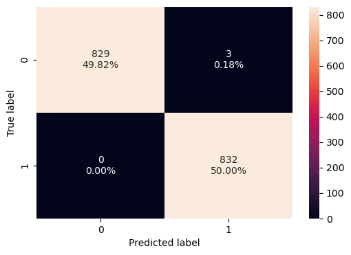

```python
confusion_matrix_sklearn(xgb_tuned_un, X_train_un,y_train_un)
```

```python
xgb_tuned_un_train = model_performance_classification_sklearn(xgb_tuned_un, X_train_un,y_train_un)
xgb_tuned_un_train
```

|  | Accuracy | Recall | Precision | F1 |
| --- | --- | --- | --- | --- |
| 0 | 0.998 | 1.000 | 0.996 | 0.998 |

#### Checking models performance on validation set

[figure not shown]

```python
confusion_matrix_sklearn(xgb_tuned_un, X_train_un,y_train_un)
```

```python
xgb_tuned_un_val = model_performance_classification_sklearn(xgb_tuned_un, X_val,y_val)
xgb_tuned_un_val
```

|  | Accuracy | Recall | Precision | F1 |
| --- | --- | --- | --- | --- |
| 0 | 0.879 | 0.906 | 0.303 | 0.454 |

Observation:

## Model performance comparison and choosing the final model

### Comparing model performances of training set

```python
Models_train_comp_df = pd.concat(
    [
        abc_tuned_model_train.T,
        gb_tuned_model_train.T,
        gb_tuned_un_train.T,
        gb_tuned_un2_train.T,
        rf_tuned_un_train.T,
        xgb_tuned_un_train.T,

    ],
    axis=1,
)
Models_train_comp_df.columns = [

    "Tuned Adaboost Classifier_over",
    "Tuned Gradient Boost Classifier_over",
    "Tuned Gradient BoostClassifier_un",
    "Tuned Gradient BoostClassifier_un2",
    "Tuned Random Forest_un",
    "XGBoost Classifier Tuned_un"

]
print("Training performance comparison:")
Models_train_comp_df
```

```
Training performance comparison:
```

|  | Tuned Adaboost Classifier_over | Tuned Gradient Boost Classifier_over | Tuned Gradient BoostClassifier_un | Tuned Gradient BoostClassifier_un2 | Tuned Random Forest_un | XGBoost Classifier Tuned_un |
| --- | --- | --- | --- | --- | --- | --- |
| Accuracy | 0.992 | 0.993 | 0.995 | 1.000 | 0.961 | 0.998 |
| Recall | 0.988 | 0.993 | 0.990 | 1.000 | 0.933 | 1.000 |
| Precision | 0.995 | 0.994 | 1.000 | 1.000 | 0.989 | 0.996 |
| F1 | 0.992 | 0.993 | 0.995 | 1.000 | 0.960 | 0.998 |

### Comparing model performances on validation set

```python
Models_val_comp_df = pd.concat(
    [
        abc_tuned_model_val.T,
        gb_tuned_model_val.T,
        gb_tuned_un_val.T,
        gb_tuned_un2_val.T,
        rf_tuned_un_val.T,
        xgb_tuned_un_val.T,

    ],
    axis=1,
)
Models_val_comp_df.columns = [

    "Tuned Adaboost Classifier_over",
    "Tuned Gradient Boost Classifier_over",
    "Tuned Gradient BoostClassifier_un",
    "Tuned Gradient BoostClassifier_un2",
    "Tuned Random Forest_un",
    "XGBoost Classifier Tuned_un"

]
print("Training performance comparison:")
Models_val_comp_df
```

```
Training performance comparison:
```

|  | Tuned Adaboost Classifier_over | Tuned Gradient Boost Classifier_over | Tuned Gradient BoostClassifier_un | Tuned Gradient BoostClassifier_un2 | Tuned Random Forest_un | XGBoost Classifier Tuned_un |
| --- | --- | --- | --- | --- | --- | --- |
| Accuracy | 0.979 | 0.971 | 0.923 | 0.925 | 0.938 | 0.879 |
| Recall | 0.853 | 0.845 | 0.881 | 0.878 | 0.885 | 0.906 |
| Precision | 0.790 | 0.693 | 0.412 | 0.418 | 0.468 | 0.303 |
| F1 | 0.820 | 0.762 | 0.561 | 0.566 | 0.612 | 0.454 |

**Observations**:

1. The XGBoost Tuned model for undersampled is giving the highest performance score of 0.90 on the Validation Set.
2. Although this algorithm has recall of 1 for training set indicating overfitting, we still observe the following
3. The random forest hypertuned model has doing quite well on validation data with recall of .885 and accuracy of .938.
4. As accuracy on training set is .96 and recall is .93 model is not much overfitted and quite close score on validation data.

### Test set final performance

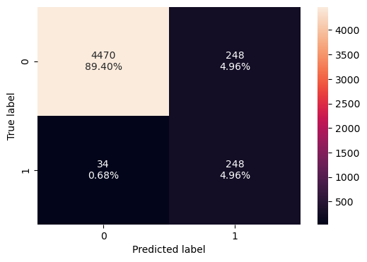

```python
confusion_matrix_sklearn(rf_tuned,X_test,y_test)
```

```python
rf_tuned_test = model_performance_classification_sklearn(rf_tuned, X_test, y_test)
rf_tuned_test
```

|  | Accuracy | Recall | Precision | F1 |
| --- | --- | --- | --- | --- |
| 0 | 0.944 | 0.879 | 0.500 | 0.638 |

**Observation**:

1. The random forest tuned model performed very well on test data with recall of .879 and accuracy of .944.
2. The performance of this model with undersampling is less cumputational extensive as well.

### Important features of the final model

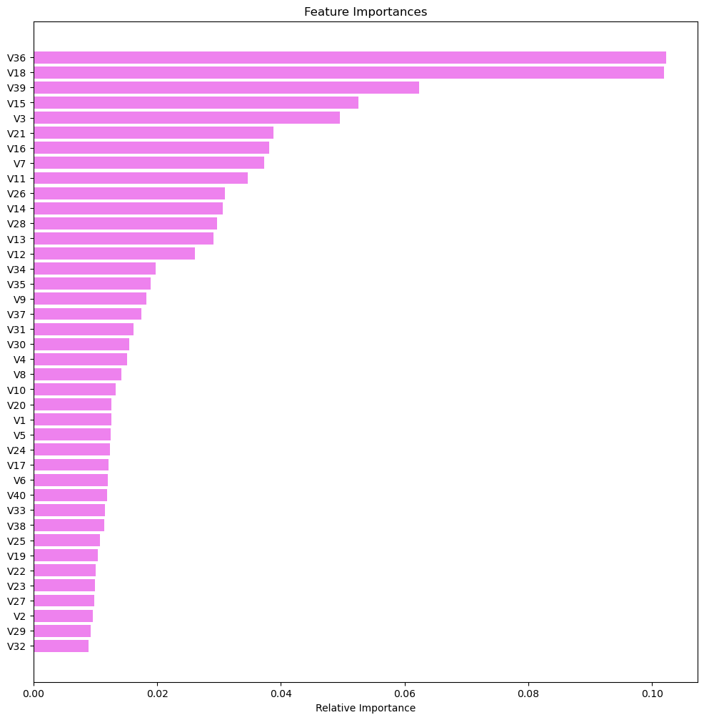

```python
#plot the important features of final model
feature_names = X_train.columns
importances = rf_tuned.feature_importances_
indices = np.argsort(importances)

plt.figure(figsize=(12, 12))
plt.title("Feature Importances")
plt.barh(range(len(indices)), importances[indices], color="violet", align="center")
plt.yticks(range(len(indices)), [feature_names[i] for i in indices])
plt.xlabel("Relative Importance")
plt.show()
```

## Pipelines to build the final model

*Now that we have a final model, let's use pipelines to put the model into production. We know that we can use pipelines to standardize the model building, but the steps in a pipeline are applied to each and every variable*

- Since we have only one datatype that is numerical data, we don't need to use column transformer here

```python
# Dividing train data into X and y
X_pipe = Train_data.drop(["Target"], axis=1)
y_pipe = Train_data["Target"]
```

```python
# Dividing test data into X_test and y_test
X_pipetest = Test_data.drop(['Target'], axis = 1)
y_pipetest = Test_data['Target']
```

```python
X_pipe.shape, X_pipetest.shape, y_pipe.shape
```

```
((20000, 40), (5000, 40), (20000,))
```

```python
X_pipe.isnull().sum()
```

```
V1     18
V2     18
V3      0
V4      0
V5      0
V6      0
V7      0
V8      0
V9      0
V10     0
V11     0
V12     0
V13     0
V14     0
V15     0
V16     0
V17     0
V18     0
V19     0
V20     0
V21     0
V22     0
V23     0
V24     0
V25     0
V26     0
V27     0
V28     0
V29     0
V30     0
V31     0
V32     0
V33     0
V34     0
V35     0
V36     0
V37     0
V38     0
V39     0
V40     0
dtype: int64
```

**Observations**:

1. There are 18 missing values in v1 and v2.

## Pipeline

```python
#treating missing values with imputer
X_pipe = pd.DataFrame(imputer.fit_transform(X_pipe))
X_pipe.isnull().sum()
```

```
0     0
1     0
2     0
3     0
4     0
5     0
6     0
7     0
8     0
9     0
10    0
11    0
12    0
13    0
14    0
```

[output cut: 26 more lines]

```python
 # Under Sampling Technique
rus = RandomUnderSampler(random_state=1, sampling_strategy=1)
X_pipe_un, y_pipe_un = rus.fit_resample(X_train, y_train)
```

#### Pipeline for preprocessing steps for training data

```python
preprocessor = Pipeline(steps=[
    ("imputer", SimpleImputer(strategy="median")),
    ("Rus", RandomUnderSampler(random_state=1, sampling_strategy=1)),
     ])
```

```python
preprocessor.fit(X_pipe, y_pipe)
```

```
Pipeline(steps=[('imputer', SimpleImputer(strategy='median')),
                ('Rus',
                 RandomUnderSampler(random_state=1, sampling_strategy=1))])
```

*Preprocessor pipeline is created for training dataset as only training data will be randomly undersampled for modeling*

#### Pipeline for transform and modeling

```python
model_pipeline = Pipeline(
    steps=[
        ("imputer", SimpleImputer(strategy="median")),
        ("RF", RandomForestClassifier(
                    max_samples=0.5,
                    min_samples_leaf=2,
                    n_estimators=300,
                     oob_score=True,
                     random_state=1
            ),
        ),
    ]
)
```

```python
# Fit the model on training data
model_pipeline.fit(X_pipe_un, y_pipe_un)
```

```
Pipeline(steps=[('imputer', SimpleImputer(strategy='median')),
                ('RF',
                 RandomForestClassifier(max_samples=0.5, min_samples_leaf=2,
                                        n_estimators=300, oob_score=True,
                                        random_state=1))])
```

```python
model_pipeline.predict(X_pipetest)
```

```
array([0, 0, 0, ..., 0, 0, 0], dtype=int64)
```

```python
pipe_test = model_performance_classification_sklearn(model_pipeline, X_pipetest, y_pipetest)
pipe_test
```

|  | Accuracy | Recall | Precision | F1 |
| --- | --- | --- | --- | --- |
| 0 | 0.944 | 0.879 | 0.500 | 0.638 |

**Observation**:

1. The model_pipeline is giving exactly same test performance as rf_tuned model with recall of .879 and accuracy of .944.
2. The pipeline model can directly use on production dataset and missing values will be imputed in the model itself.

# Business Insights and Conclusions

**Best model and its performance**

~ The objective was to build a classification model that can accurately predict the components failures beforehand so parts could be repaired instead of being replaced. High recall score for the model will reduce the false negatives which usuually lead to high replacement costs.

~ Higher accuracy and recall will help in correctly predicting true failure beforehand through the model which will eventually reduce the total maintenance cost for wind energy production.

~ To handle class imbalance for the "Target" attribute, two techniques are used

- Synthetic Minority Oversampling Technique (SMOTE) is used to generate synthetic data points for minority class.
- Random Undersampling, in which only few random samples from the majority class are chosen for modelling.

~ The rf_tuned (Random forest) model build from undersampled training set is chosen with high accuracy and recall values after comparing results from different algorithms. The high recall value of .88 means only 12% chance is there that failure might not be detected by the model

~ The model_pipeline is additionally built to use model on production data directly.

**Important features**

1. The main attributes of importance for predicting failures vs. no failures are V36 and V18. After these two features next set of features which are important in random forest model are V39, V15 and V3.
2. V21, V21, V16, V7, V11, V26, V14, V28, V13, V12 are few other features in descending order of their importance.
3. The data which refer to these numerical features should be priortized and need to be updated frequently inorder to keep improving the machine learning model for better performance.

*Additional points*

1. Other models like tuned Adaboost and Gradient boost build from SMOTE training data are good performing models as well with high acuracy and recall scores. The XGboost model build from undersampled training dataset is good model too with quite high recall score.
2. These models can be further tested as well to compare their important features.